# 4B Movement Project_ Web Page

Yiran Zhang

2025-04-14

## Project Description

This page introduces my project on 4B movement in North America.

The 4B movement is a radical feminist movement that originated in South Korea between 2017 to 2019. It advocates for no marriage, no childbirth, no date with men, and no sex with men. This movement aims to reject traditional gender roles and patriarchal culture in South Korea. During the 2024 presidential election, this movement spreads to the US. In this project, I aim to study the trends, themes, and emotions of North American media in reporting on the 4B movement.

## Data & Method

This study draws on data from newspaper articles. I searched “4B movement” in NexisUni and retrieved 317 English articles that was published in the North America. After cleaning the data and deleting the duplicate ones, the final sample size is 242.

The analysis includes two parts. First, I clean the data and provide the descriptive results of my sample. Second, for the preliminary analysis, I conducted bigrams and sentiment analysis, content analysis and topic analysis.

#### Bigrams and sentiment analysis

Research Questions: RQ1: What are the most common word pairs in the reports on 4B movement? RQ2: What sentiments can be identified?

#### Content analysis

RQ1: What percentage of coverage was a) prior to the presidential election; b) during the election period; and c) after the election? RQ2: What percentage of those sentences portrayed 4B movement in a negative way? And what percentage portrayed it in a positive way? RQ3: What percentage of the coverage was opinion? And what percentage of them are news?

Codebook:

RQ1: The cutoff data for presidential election: a) prior_election: publication data was before 10-31-2024 b) during_election: publication data was from 11-1-2024 to 11-30-2024 c) after_election: publication data was after 12-1-2024.

RQ2: The presence of specific negative or positive words: a) negative_frame: sentence include negative keywords of “hate”, “extreme”, “crazy”, “selfish”, “toxic”, “anti-family”, “anti-men”, “anti-social”, and “against tradition”. b) positive_frame: sentence include positive keywords of “brave”, “independent”, “empowered”, “rational”, “modern”, “free”, “freedom”, “autonomy”, “self-determined”, and “social progress”.

RQ3: The type of coverage: a) news: section contains the keywords of news; b) opinion: section contains the keywords of opinion.

#### Topic analysis

Research Questions RQ1: What are the key themes among those articles on the 4B movement? RQ2: How do these key themes vary across time periods (before, during, and after the presidential election)?

## Sample & descriptive statistics

```r
# set options
options(stringsAsFactors = F)         # no automatic data transformation
options("scipen" = 100, "digits" = 4) # suppress math annotation
# load packages
here::here()
```

```
## [1] "/Users/yiranzhang/Desktop/code/com_text_class/4B_Movement_Project"
```

```r
library(tidyverse)
library(tidytext)
library(rio)
library(readtext)
library(janitor)
#topic modeling
library(quanteda)
library(tm)
library(topicmodels)
library(lda)
library(ldatuning)
# from tutorial packages
library(DT)
library(knitr)
library(kableExtra)
library(reshape2)
```

```r
library(ggplot2)
library(wordcloud)
library(pals)
library(SnowballC)
library(flextable)
#Import spreadsheet using rio::import and clean the names

project <- import("FullArticles_4.14.csv")
```

```r
names(project)
```

```
##  [1] "V1"                   "filename"             "sentence"
##  [4] "title"                "published_date"       "publication_location"
##  [7] "publication_4"        "publication_type_5"   "length"
## [10] "section"              "word_count"           "countries"
## [13] "byline"               "agg_copyright"        "cite"
## [16] "company"              "headline"             "hlead"
## [19] "publication_16"       "publication_type_17"  "pub_copyright"
## [22] "show"                 "term"                 "ticker"
## [25] "index"                "filepath"
```

```r
project <- clean_names(project)

project <- project %>%
  mutate(date_clean = mdy(str_remove(published_date, " \\w+$")),
         year = year(date_clean))
```

#### Introduce my sample

```r
print(paste0("My sample contains ", nrow(project), " rows and ", ncol(project), " columns with ", n_distinct(project$title), " unique articles."))
```

```
## [1] "My sample contains 8051 rows and 28 columns with 242 unique articles."
```

#### Frequency Tables

The frequency table for the top 10 location is:

```r
# By Locations
project %>%
  group_by(title) %>%
  slice_head(n = 1) %>%
  ungroup() %>%
  count(publication_location, sort = TRUE) %>%
  head(10)
```

```
## # A tibble: 10 × 2
##    publication_location     n
##    <chr>                <int>
##  1 U.S. Federal           117
##  2 International           93
##  3 New York                14
##  4 Utah                     4
##  5 California               3
##  6 Dist. of Columbia        2
##  7 Florida                  2
##  8 Georgia                  2
##  9 Pennsylvania             2
## 10 Illinois                 1
```

The frequency table for the top 10 publishers is:

```r
# By Publishers
project %>%
  group_by(title) %>%
  slice_head(n = 1) %>%
  ungroup() %>%
  count(publication_4, sort = TRUE) %>%
  head(10)
```

```
## # A tibble: 10 × 2
##    publication_4                       n
##    <chr>                           <int>
##  1 WebNews - English                  48
##  2 CE Noticias Financieras English    35
##  3 University Wire                    30
##  4 Newsweek.com                       14
##  5 USA Today Online                   12
##  6 The New York Times                 10
##  7 Newstex Blogs                       9
##  8 Fox News                            7
##  9 WebNews - Academic                  7
## 10 Naked Capitalism                    4
```

#### Trends over time

The distribution of the 4B movements articles over time

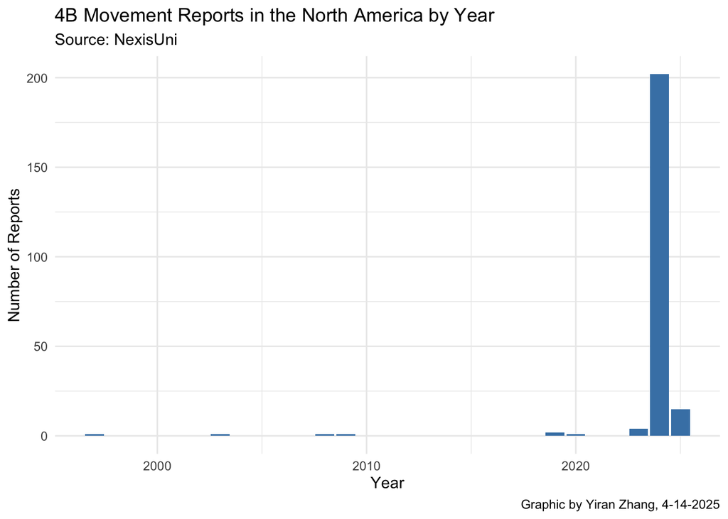

```r
project %>%
  group_by(title) %>%
  slice_head(n = 1) %>%
  ungroup() %>%
  count(year) %>%
  ggplot(aes(x = year, y = n)) +
  geom_col(fill = "steelblue") +
  labs(title = "4B Movement Reports in the North America by Year",
       subtitle = "Source: NexisUni",
       caption = "Graphic by Yiran Zhang, 4-14-2025",
       y="Number of Reports",
       x="Year") +
  theme_minimal()
```

Since most of those articles were published between 2023 and 2025, I filtered the dataset to only include articles that were published during this time.

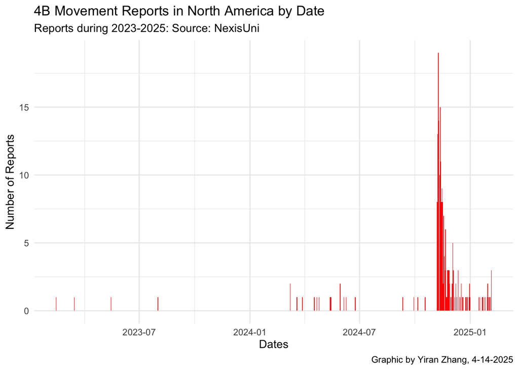

```r
project %>%
  group_by(title) %>%
  slice_head(n = 1) %>%
  ungroup() %>%
  filter(year >= 2023 & year <= 2025) %>%
  count(date_clean) %>%
  ggplot(aes(x = date_clean, y = n)) +
  geom_col(fill = "red") +
  labs(title = "4B Movement Reports in North America by Date",
       subtitle = "Reports during 2023-2025: Source: NexisUni",
       caption = "Graphic by Yiran Zhang, 4-14-2025",
       y = "Number of Reports",
       x = "Dates") +
  theme_minimal()
```

## Preliminary Result

#### Bigrams & Sentiment Analysis

```r
sentence <- str_replace_all(project$sentence, "- ", "")
sentence_tk <- tibble(sentence,)

sentence_tokenized <- sentence_tk %>%
  unnest_tokens(word,sentence)

sentence_tokenized
```

```
## # A tibble: 267,151 × 1
##    word
##    <chr>
##  1 lily
##  2 huynh
##  3 the
##  4 cougar
##  5 months
##  6 ago
##  7 american
##  8 women
##  9 algorithms
## 10 and
## # ℹ 267,141 more rows
```

```r
stopwords <- stop_words
stopwords
```

```
## # A tibble: 1,149 × 2
##    word        lexicon
##    <chr>       <chr>
##  1 a           SMART
##  2 a's         SMART
##  3 able        SMART
##  4 about       SMART
##  5 above       SMART
##  6 according   SMART
##  7 accordingly SMART
##  8 across      SMART
##  9 actually    SMART
## 10 after       SMART
## # ℹ 1,139 more rows
```

```r
stopwords |>
  count(lexicon)
```

```
## # A tibble: 3 × 2
##   lexicon      n
##   <chr>    <int>
## 1 SMART      571
## 2 onix       404
## 3 snowball   174
```

```r
data(stop_words)

sentence_tokenized <- sentence_tokenized %>%
  anti_join(stop_words, by = c("word" = "word")) %>%
  filter(word != "temp_file") %>%
  filter(word != "stories_corpus") %>%
  filter(!grepl('[0-9]', word))

# Word Count

sentence_word_ct <- sentence_tokenized %>%
  count(word, sort=TRUE)

sentence_word_ct
```

```
## # A tibble: 14,864 × 2
##    word          n
##    <chr>     <int>
##  1 women      1903
##  2 trump      1042
##  3 movement    953
##  4 people      658
##  5 sex         644
##  6 south       591
##  7 president   514
##  8 election    489
##  9 donald      403
## 10 time        391
## # ℹ 14,854 more rows
```

```r
write_csv(sentence_word_ct, "sentence_word_ct.csv")
```

```r
bigrams <- sentence_tk %>%
  unnest_tokens(bigram, sentence, token="ngrams", n=2)

bigrams
```

```
## # A tibble: 260,643 × 1
##    bigram
##    <chr>
##  1 lily huynh
##  2 huynh the
##  3 the cougar
##  4 months ago
##  5 ago american
##  6 american women
##  7 women algorithms
##  8 algorithms and
##  9 and publications
## 10 publications turned
## # ℹ 260,633 more rows
```

```r
#Filter out stop words.

bigrams1 <- bigrams %>%
  separate(bigram, c("word1", "word2"), sep = " ")

bigrams2 <- bigrams1 %>%
  filter(!word1 %in% stop_words$word) %>%
  filter(!word2 %in% stop_words$word) |>
  filter(!is.na(word1)) |>
  filter(!is.na(word2))

bigram3 <- bigrams2 %>%
  count(word1, word2, sort = TRUE)

bigram3
```

```
## # A tibble: 30,306 × 3
##    word1         word2             n
##    <chr>         <chr>         <int>
##  1 4b            movement        502
##  2 south         korea           319
##  3 donald        trump           276
##  4 south         korean          152
##  5 authoritative content         135
##  6 newstex       authoritative   135
##  7 social        media           124
##  8 donald        trump's          96
##  9 president     elect            96
## 10 video         clip             90
## # ℹ 30,296 more rows
```

Based on these high-frequency bigrams, I found several key themes in this dataset. The first group of keywords focuses on what the movement is and what its key concerns are, such as “4B movement,” “feminist movement,” “radical feminist,” “gender equality,” “sex strike,” “abortion rights,” “reproductive rights,” etc. The second group of keywords is about countries and context, which includes “South Korea,” “Korean women,” “American women,” and “American people.” The third group of keywords is about political figures and events, such as “Donald Trump,” “Kamala Harris,” “Joe Biden,” “White House,” “President Elect,” “Yoon Suk,” etc., suggesting that the emergence of the 4B Movement in the U.S. is highly related to the political context, especially the presidential election.

#### Sentiment Analysis

Tokenize sentence into a df, remove stopwords

```r
# cite this lexicon
#install.packages("textdata")
nrc_sentiments <- get_sentiments("nrc")
afinn_sentiments <- get_sentiments("afinn")

nrc_sentiments %>%
  count(sentiment, sort = TRUE)
```

```
## # A tibble: 10 × 2
##    sentiment        n
##    <chr>        <int>
##  1 negative      3316
##  2 positive      2308
##  3 fear          1474
##  4 anger         1245
##  5 trust         1230
##  6 sadness       1187
##  7 disgust       1056
##  8 anticipation   837
##  9 joy            687
## 10 surprise       532
```

```r
sentiments_all <- sentence_tokenized %>%
  inner_join(nrc_sentiments, by = "word")
sentence_tokenized %>%
  inner_join(nrc_sentiments) %>%
  count(word, sort = TRUE)
```

```
## # A tibble: 2,735 × 2
##    word          n
##    <chr>     <int>
##  1 sex        2576
##  2 marriage   1148
##  3 trump      1042
##  4 president  1028
##  5 abortion   1016
##  6 content     888
##  7 vote        872
##  8 violence    668
##  9 share       504
## 10 victory     496
## # ℹ 2,725 more rows
```

```r
sentiments_all %>%
  count(sentiment, sort = TRUE)
```

```
## # A tibble: 10 × 2
##    sentiment        n
##    <chr>        <int>
##  1 positive     14290
##  2 trust         9604
##  3 negative      8136
##  4 anticipation  6156
##  5 fear          5104
##  6 joy           4971
##  7 anger         4106
##  8 sadness       3846
##  9 surprise      2970
## 10 disgust       2327
```

```r
over_sen <-sentiments_all %>%
  count(sentiment, sort = TRUE)
```

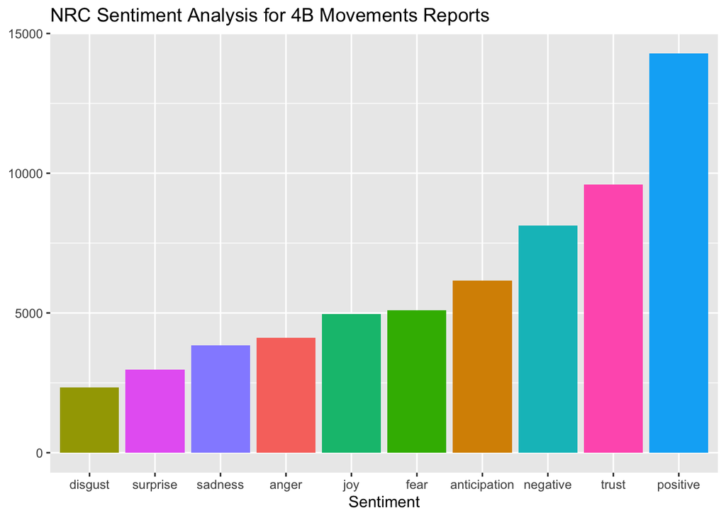

```r
ggplot(over_sen, aes(x = reorder(sentiment,n), y = n, fill = sentiment)) +
  geom_col(show.legend = FALSE) +
  labs(title = "NRC Sentiment Analysis for 4B Movements Reports",
       x = "Sentiment",
       y = NULL)
```

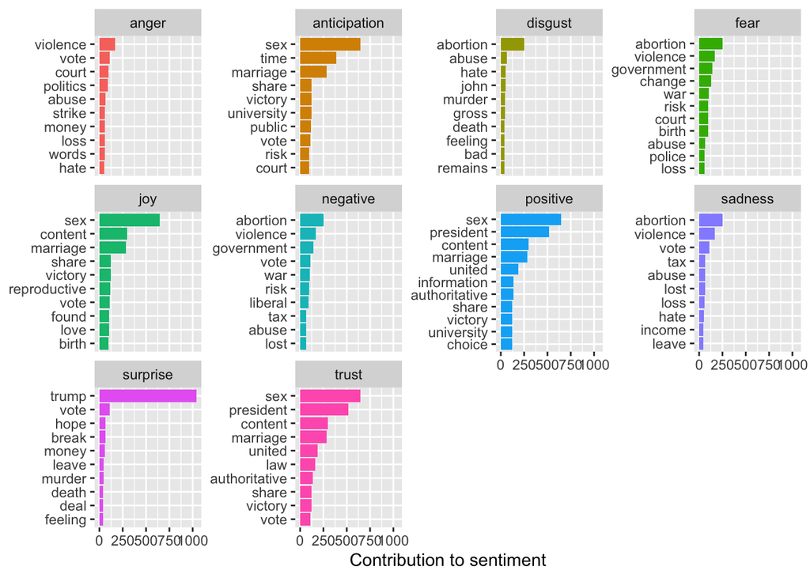

```r
sentiments_all %>%
  count(sentiment, word) %>%
  group_by(sentiment) %>%
  slice_max(n, n = 10) %>%
  ungroup() %>%
  mutate(word = reorder_within(word, n, sentiment)) %>%
  ggplot(aes(n, word, fill = sentiment)) +
  geom_col(show.legend = FALSE) +
  facet_wrap(~sentiment, scales = "free_y") +
  scale_y_reordered() +
  labs(x = "Contribution to sentiment",
       y = NULL)
```

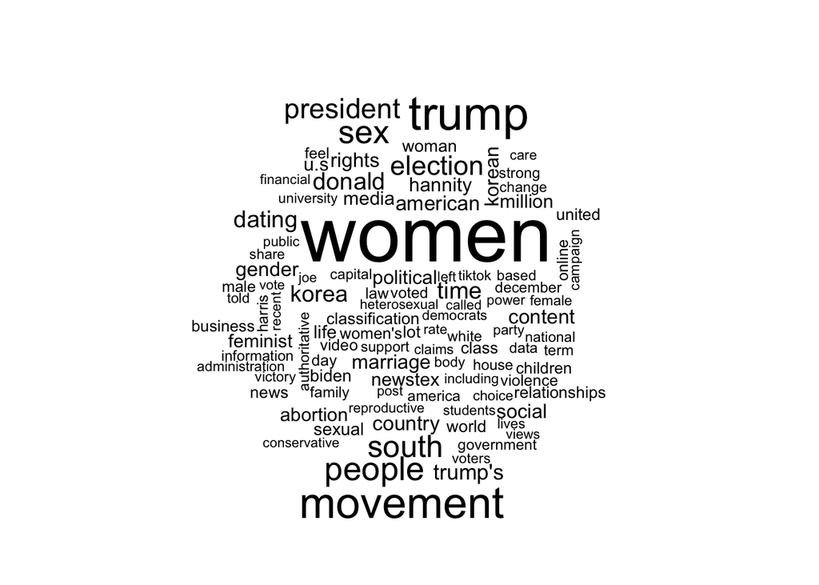

```r
library(wordcloud)

sentence_tokenized %>%
  anti_join(stop_words) %>%
  count(word) %>%
  with(wordcloud(word, n, max.words = 100))
```

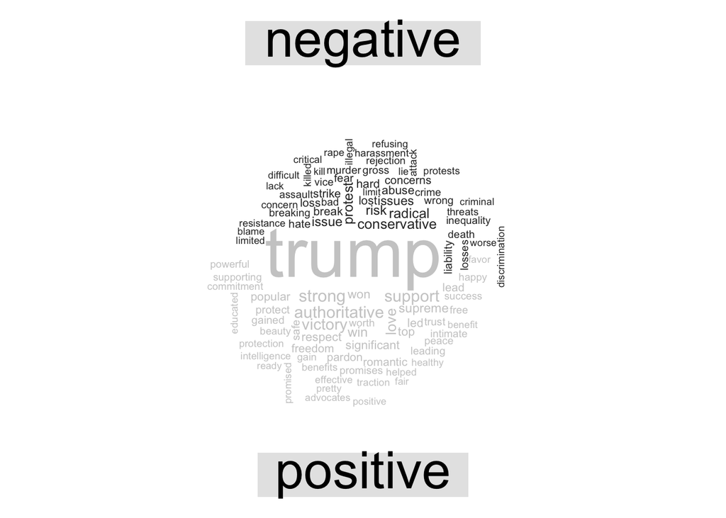

```r
library(reshape2)

sentence_tokenized %>%
  inner_join(get_sentiments("bing")) %>%
  count(word, sentiment, sort = TRUE) %>%
  acast(word ~ sentiment, value.var = "n", fill = 0) %>%
  comparison.cloud(colors = c("gray20", "gray80"),
                   max.words = 100)
```

#### Content Analysis

Create variables for time period and sentiment.

```r
project <- project |>
  mutate(RQ1 = case_when(
    date_clean < ymd("2024-11-01") ~ "prior_election",
    date_clean >= ymd("2024-11-01") & date_clean <= ymd("2024-11-30") ~ "during_election",
    date_clean >= ymd("2024-12-01") ~ "after_election",
    TRUE ~ "unknown"
  ))
```

```r
project <- project |>
  mutate(RQ2_positive = case_when(
  str_detect(sentence, "brave|independent|empowered|rational|modern|free|freedom|autonomy|self[- ]?determined|social progress") ~ 1,
  TRUE ~ 0
  ))

project <- project |>
  mutate(RQ2_negative = case_when (
  str_detect(sentence, "hate|extreme|crazy|selfish|toxic|anti[- ]?family|anti[- ]?men|anti[- ]?social|against tradition") ~ 1,
  TRUE ~ 0
  ))
```

```r
project <- project %>%
  mutate(type = case_when(
    str_detect(tolower(section), "op") ~ "opinion",
    str_detect(tolower(section), "news") ~ "news"
  ))

project %>%
  count(type, sort = TRUE)
```

```
##      type    n
## 1    <NA> 5017
## 2    news 2717
## 3 opinion  317
```

```r
project %>%
  group_by(title) %>%
  slice_head(n = 1) %>%
  ungroup() -> article_level
article_level <- project %>%
  group_by(title) %>%
  slice_head(n = 1) %>%
  ungroup()

print(paste0(
  "RQ1: The percentage of coverage published prior to the presidential election was ",  round(prop.table(table(article_level$RQ1))["prior_election"] * 100, 1), "%; ",  "during the election period was ",  round(prop.table(table(article_level$RQ1))["during_election"] * 100, 1), "%; ",  "after the election was ",  round(prop.table(table(article_level$RQ1))["after_election"] * 100, 1), "%."
))
```

```
## [1] "RQ1: The percentage of coverage published prior to the presidential election was 12.4%; during the election period was 63.6%; after the election was 18.2%."
```

```r
print(paste0(
  "RQ2: The percentage of sentence that portrayed 4B movement in a negative way was ",  round(prop.table(table(project$RQ2_negative))[["1"]]*100, 1), "%; ",  "in a positive way was ",  round(prop.table(table(project$RQ2_positive))[["1"]]* 100, 1), "%."
))
```

```
## [1] "RQ2: The percentage of sentence that portrayed 4B movement in a negative way was 2.1%; in a positive way was 2.7%."
```

```r
print(paste0(
  "RQ3: The percentage of opinion coverage was ",  round(prop.table(table(article_level$type))["opinion"] * 100, 1), "%; ",  " the percentage of news coverage was ",  round(prop.table(table(article_level$type))["news"] * 100, 1), "%. "
))
```

```
## [1] "RQ3: The percentage of opinion coverage was 28.3%;  the percentage of news coverage was 71.7%. "
```

#### Topic Analysis:

```r
textdata <- project %>%
  select(filename, sentence, date_clean) %>%
  as.data.frame() %>%
  rename(doc_id = filename, text= sentence)

# load stopwords
english_stopwords <- readLines("https://slcladal.github.io/resources/stopwords_en.txt", encoding = "UTF-8")
# create corpus object
corpus <- Corpus(DataframeSource(textdata))
# Preprocessing chain
processedCorpus <- tm_map(corpus, content_transformer(tolower))
processedCorpus <- tm_map(processedCorpus, removeWords, english_stopwords)
processedCorpus <- tm_map(processedCorpus, removePunctuation, preserve_intra_word_dashes = TRUE)
#processedCorpus <- tm_map(processedCorpus, removeNumbers) Because 4B movement has numbers in the name, so I skip this
processedCorpus <- tm_map(processedCorpus, stemDocument, language = "en")
processedCorpus <- tm_map(processedCorpus, stripWhitespace)
```

```r
# compute document term matrix with terms >= minimumFrequency
minimumFrequency <- 5
DTM <- DocumentTermMatrix(processedCorpus, control = list(bounds = list(global = c(minimumFrequency, Inf))))
# have a look at the number of documents and terms in the matrix
dim(DTM)
```

```
## [1] 8051 3275
```

```r
# due to vocabulary pruning, we have empty rows in our DTM
# LDA does not like this. So we remove those docs from the
# DTM and the metadata
sel_idx <- slam::row_sums(DTM) > 0
DTM <- DTM[sel_idx, ]
textdata <- textdata[sel_idx, ]
```

```r
textdata <- textdata |>
  mutate(time = case_when(
    date_clean < ymd("2024-11-01") ~ "prior_election",
    date_clean >= ymd("2024-11-01") & date_clean <= ymd("2024-11-30") ~ "during_election",
    date_clean >= ymd("2024-12-01") ~ "after_election",
    TRUE ~ "unknown"
  ))

articles_time <- textdata %>%
  distinct(doc_id, .keep_all=TRUE) %>%
  count(time) %>%
  mutate(pct_total= (n/sum(n))) %>%
  mutate(pct_total= formattable::percent(pct_total)) %>%
  # mutate(pct_total = round(pct_total, 1)) %>%
  arrange(desc(time))

library(kableExtra)
articles_time %>%
  kbl(caption = "4B Articles by time", font_size = 30) %>%
  kable_classic(full_width = F, html_font = "Cambria") %>%
  column_spec(1, bold = T, border_right = T) %>%
  column_spec(2, width = "5em") %>%
  column_spec(3, width = "5em", background = "yellow")
```

4B Articles by time

| time | n | pct_total |
| --- | --- | --- |
| unknown | 14 | 5.79% |
| prior_election | 30 | 12.40% |
| during_election | 154 | 63.64% |
| after_election | 44 | 18.18% |

```r
#Fact check 9589 articles
#sum(articles_times$n)
```

```r
# number of topics
K <- 4
# set random number generator seed
set.seed(9999)
#Latent Dirichlet Allocation, LDA
topicModel2 <- LDA(DTM, K, method="Gibbs", control=list(iter = 500, verbose = 25, alpha = 0.2))
```

```
## K = 4; V = 3275; M = 7317
## Sampling 500 iterations!
## Iteration 25 ...
## Iteration 50 ...
## Iteration 75 ...
## Iteration 100 ...
## Iteration 125 ...
## Iteration 150 ...
## Iteration 175 ...
## Iteration 200 ...
## Iteration 225 ...
## Iteration 250 ...
## Iteration 275 ...
## Iteration 300 ...
## Iteration 325 ...
## Iteration 350 ...
## Iteration 375 ...
## Iteration 400 ...
## Iteration 425 ...
## Iteration 450 ...
## Iteration 475 ...
## Iteration 500 ...
## Gibbs sampling completed!
```

```r
tmResult <- posterior(topicModel2)
theta <- tmResult$topics
beta <- tmResult$terms
topicNames <- apply(terms(topicModel2, 10), 2, paste, collapse = " ")  # reset topicnames
```

```r
# Step 1: Check dimensions
n_theta <- nrow(theta)
n_textdata <- length(textdata$time)

cat("Number of rows in theta: ", n_theta, "\n")
```

```
## Number of rows in theta:  7317
```

```r
cat("Number of documents in textdata: ", n_textdata, "\n")
```

```
## Number of documents in textdata:  7317
```

```r
# Check if textdata contains all the documents in theta
common_ids <- intersect(rownames(theta), textdata$doc_id) # Assuming textdata has a 'doc_id' column

# Filter textdata to include only the documents present in theta
textdata_filtered <- textdata[textdata$doc_id %in% common_ids, ]

# Check dimensions after filtering
n_textdata_filtered <- nrow(textdata_filtered)
cat("Number of documents in filtered textdata: ", n_textdata_filtered, "\n")
```

```
## Number of documents in filtered textdata:  7317
```

```r
# Ensure the lengths match now
if (n_theta != n_textdata_filtered) {
  stop("The number of rows in 'theta' still does not match the length of 'textdata_filtered$time'.")
}

# Align rownames of theta with filtered textdata
theta_aligned <- theta[rownames(theta) %in% textdata_filtered$doc_id, ]

# Optional: Verify the order of documents
if (!all(rownames(theta_aligned) == textdata_filtered$doc_id)) {
  # If the order doesn't match, reorder one to match the other
  textdata_filtered <- textdata_filtered[match(rownames(theta_aligned), textdata_filtered$doc_id), ]
}

# Ensure they are now aligned and can be combined
if (!all(rownames(theta_aligned) == textdata_filtered$doc_id)) {
  stop("The document IDs still do not match. Please check the data alignment.")
}

# Step 2: Combine data
topic_data <- data.frame(theta_aligned, time = textdata_filtered$time)

# Step 3: Aggregate data
topic_proportion_per_time <- aggregate(. ~ time, data = topic_data, FUN = mean)

# get mean topic proportions per time
# set topic names to aggregated columns
colnames(topic_proportion_per_time)[2:(K+1)] <- topicNames
# reshape data frame
vizDataFrame <- melt(topic_proportion_per_time, id.vars = "time")
```

```r
#enframe(): Converts a named list into a dataframe.
topics <- enframe(topicNames, name = "number", value = "text") %>%
  unnest(cols = c(text))

topics
```

```
## # A tibble: 4 × 2
##   number  text
##   <chr>   <chr>
## 1 Topic 1 trump peopl presid donald hanniti time state biden elect democrat
## 2 Topic 2 million group year busi 2008 student rate share capit decemb
## 3 Topic 3 women men movement sex trump date elect polit young abort
## 4 Topic 4 south movement women korea content korean newstex men feminist marriag
```

```r
#add categories

vizDataFrame <- vizDataFrame %>%
  mutate(category = case_when(
    str_detect(variable,  "trump peopl presid donald hanniti time state biden elect democrat") ~ "Political_figure_event",
    str_detect(variable, "south movement women korea content korean newstex men feminist marriag") ~ "4B_movement",
    str_detect(variable, "million group year busi 2008 student rate share capit decemb") ~ "Capitalism",
    str_detect(variable, "women men movement sex trump date elect polit young abort") ~ "Gender_issues",
    ))
```

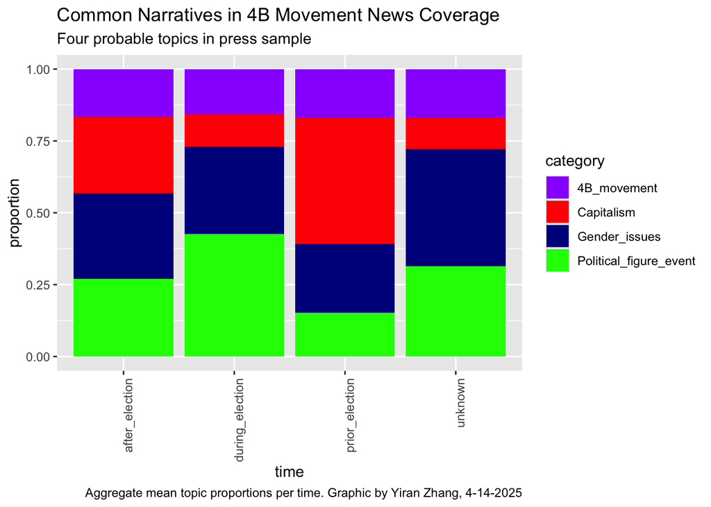

```r
# plot topic proportions per time as bar plot
ggplot(vizDataFrame, aes(x=time, y=value, fill=category)) +
  geom_bar(stat = "identity") + ylab("proportion") +
  scale_fill_manual(values = paste0(alphabet(20), "FF"), name = "time") +
  theme(axis.text.x = element_text(angle = 90, hjust = 1)) +
   scale_fill_manual(values=c("#9933FF",
                              "red",
                              "darkblue",
                              "green"))+
  labs(title = "Common Narratives in 4B Movement News Coverage",
       subtitle = "Four probable topics in press sample",
       caption = "Aggregate mean topic proportions per time. Graphic by Yiran Zhang, 4-14-2025")
```

Based on topic analysis, I identified four major topics in 4B movements reports. First, 4B_movement_context, talks about the definition and background of the movement. Second, capitalism, refers to discussions of economic conditions and the job market. The third topic is gender_issues, which focuses on the movement’s core concerns, such as abortion rights. And the last topic is political_figure_event, mainly focusing on the political backgrounds.